# Titanic Notebook

```python
#Pandas, Numpy, Seaborn, Matplotlib
import pandas as pd
import numpy as np
import matplotlib.pyplot as plt
import seaborn as sns
sns.set_style('whitegrid')
%matplotlib inline

#Sklearn packages
from sklearn.linear_model import LogisticRegression
from sklearn.svm import SVC, LinearSVC
from sklearn.ensemble import RandomForestClassifier
from sklearn.neighbors import KNeighborsClassifier
from sklearn.naive_bayes import GaussianNB
from sklearn.metrics import classification_report
```

```python
#Import CSVs
train = pd.read_csv("train.csv")
test = pd.read_csv("test.csv")
```

```python
train.head()
```

|  | PassengerId | Survived | Pclass | Name | Sex | Age | SibSp | Parch | Ticket | Fare | Cabin | Embarked |
| --- | --- | --- | --- | --- | --- | --- | --- | --- | --- | --- | --- | --- |
| 0 | 1 | 0 | 3 | Braund, Mr. Owen Harris | male | 22.0 | 1 | 0 | A/5 21171 | 7.2500 | NaN | S |
| 1 | 2 | 1 | 1 | Cumings, Mrs. John Bradley (Florence Briggs Th... | female | 38.0 | 1 | 0 | PC 17599 | 71.2833 | C85 | C |
| 2 | 3 | 1 | 3 | Heikkinen, Miss. Laina | female | 26.0 | 0 | 0 | STON/O2. 3101282 | 7.9250 | NaN | S |
| 3 | 4 | 1 | 1 | Futrelle, Mrs. Jacques Heath (Lily May Peel) | female | 35.0 | 1 | 0 | 113803 | 53.1000 | C123 | S |
| 4 | 5 | 0 | 3 | Allen, Mr. William Henry | male | 35.0 | 0 | 0 | 373450 | 8.0500 | NaN | S |

```python
test.head()
```

|  | PassengerId | Pclass | Name | Sex | Age | SibSp | Parch | Ticket | Fare | Cabin | Embarked |
| --- | --- | --- | --- | --- | --- | --- | --- | --- | --- | --- | --- |
| 0 | 892 | 3 | Kelly, Mr. James | male | 34.5 | 0 | 0 | 330911 | 7.8292 | NaN | Q |
| 1 | 893 | 3 | Wilkes, Mrs. James (Ellen Needs) | female | 47.0 | 1 | 0 | 363272 | 7.0000 | NaN | S |
| 2 | 894 | 2 | Myles, Mr. Thomas Francis | male | 62.0 | 0 | 0 | 240276 | 9.6875 | NaN | Q |
| 3 | 895 | 3 | Wirz, Mr. Albert | male | 27.0 | 0 | 0 | 315154 | 8.6625 | NaN | S |
| 4 | 896 | 3 | Hirvonen, Mrs. Alexander (Helga E Lindqvist) | female | 22.0 | 1 | 1 | 3101298 | 12.2875 | NaN | S |

Lets see what we have here.

```python
#Drop unneeded data
train = train.drop(['PassengerId','Name','Ticket'], axis=1)
test = test.drop(['Name','Ticket'], axis=1)
```

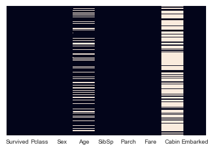

```python
sns.heatmap(data=train.isnull(),yticklabels=False,cbar=False)
```

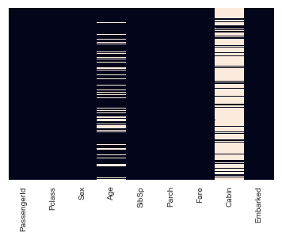

```python
sns.heatmap(data=test.isnull(),yticklabels=False,cbar=False)
```

As we can see here, both test and training data have null values in Age and Cabin. I think we will need to drop the Cabin columns as there are way too many missing values. We can fill in the age values with the mean as we have sufficient data. I think we can fill in the age values based on Pclass, as higher class may indicate higher wealth, which may indicate older people.

```python
testage = test[['Age','Pclass']]
trainage = train[['Age','Pclass']]
ages = pd.concat([testage,trainage])
ages.groupby('Pclass').mean()
```

| Pclass | Age |
| --- | --- |
| 1 | 39.159930 |
| 2 | 29.506705 |
| 3 | 24.816367 |

Here we have the mean age per class. Lets write a loop to fill in the NA age values.

```python
def fill_in_age(cols):
    age = cols[0]
    pclass = cols[1]
    if pd.isnull(age):
        if pclass==1:
            return 39.15
        elif pclass==2:
            return 29.50
        else:
            return 24.81
        return age
    else:
        return age
```

```python
train['Age'] = train[['Age','Pclass']].apply(fill_in_age,axis=1)
test['Age'] = test[['Age','Pclass']].apply(fill_in_age,axis=1)
```

```python
#Dropping Cabin and NA values.
train.drop('Cabin',inplace=True,axis=1)
train.dropna(inplace=True)
test.drop('Cabin',inplace=True,axis=1)
test.dropna(inplace=True)
```

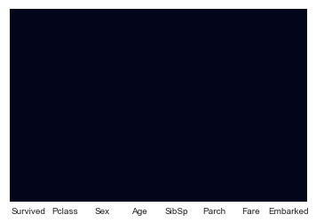

```python
sns.heatmap(data=train.isnull(),cbar=False,yticklabels=False)
```

Cleeaaaaan 8)

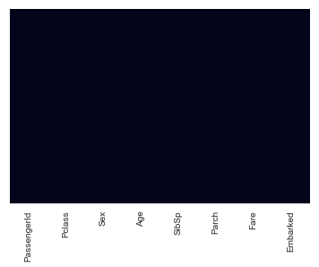

```python
sns.heatmap(data=test.isnull(),cbar=False,yticklabels=False)
```

Clean! Now it is time to format the data even further so sklearn can read it properly.

```python
trainsex = pd.get_dummies(train['Sex'],drop_first=True)
trainembark = pd.get_dummies(train['Embarked'],drop_first=True)
trainpclass = pd.get_dummies(train['Pclass'])
train = pd.concat([train,trainsex,trainembark,trainpclass],axis=1)
train = train.drop(['Sex','Embarked'],axis=1)
train.head()
```

|  | Survived | Pclass | Age | SibSp | Parch | Fare | male | Q | S | 1 | 2 | 3 |
| --- | --- | --- | --- | --- | --- | --- | --- | --- | --- | --- | --- | --- |
| 0 | 0 | 3 | 22.0 | 1 | 0 | 7.2500 | 1 | 0 | 1 | 0 | 0 | 1 |
| 1 | 1 | 1 | 38.0 | 1 | 0 | 71.2833 | 0 | 0 | 0 | 1 | 0 | 0 |
| 2 | 1 | 3 | 26.0 | 0 | 0 | 7.9250 | 0 | 0 | 1 | 0 | 0 | 1 |
| 3 | 1 | 1 | 35.0 | 1 | 0 | 53.1000 | 0 | 0 | 1 | 1 | 0 | 0 |
| 4 | 0 | 3 | 35.0 | 0 | 0 | 8.0500 | 1 | 0 | 1 | 0 | 0 | 1 |

```python
testsex = pd.get_dummies(test['Sex'],drop_first=True)
testembark = pd.get_dummies(test['Embarked'],drop_first=True)
testpclass = pd.get_dummies(test['Pclass'])
test = pd.concat([test,testsex,testembark,testpclass],axis=1)
test = test.drop(['Sex','Embarked'],axis=1)
test.head()
```

|  | PassengerId | Pclass | Age | SibSp | Parch | Fare | male | Q | S | 1 | 2 | 3 |
| --- | --- | --- | --- | --- | --- | --- | --- | --- | --- | --- | --- | --- |
| 0 | 892 | 3 | 34.5 | 0 | 0 | 7.8292 | 1 | 1 | 0 | 0 | 0 | 1 |
| 1 | 893 | 3 | 47.0 | 1 | 0 | 7.0000 | 0 | 0 | 1 | 0 | 0 | 1 |
| 2 | 894 | 2 | 62.0 | 0 | 0 | 9.6875 | 1 | 1 | 0 | 0 | 1 | 0 |
| 3 | 895 | 3 | 27.0 | 0 | 0 | 8.6625 | 1 | 0 | 1 | 0 | 0 | 1 |
| 4 | 896 | 3 | 22.0 | 1 | 1 | 12.2875 | 0 | 0 | 1 | 0 | 0 | 1 |

Keep in mind we need the PassengerID column when we make our submission.

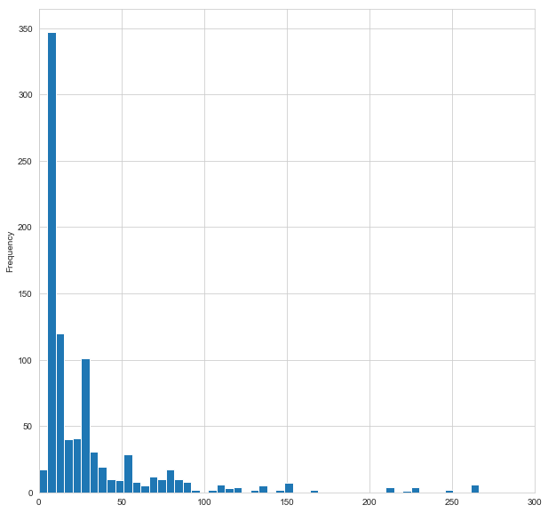

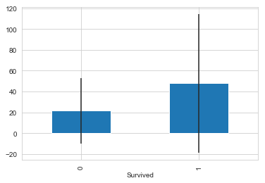

```python
#Lets do some analysis on the Fares.

#FloatInt format
train['Fare'] = train['Fare'].astype(int)
test['Fare'] = test['Fare'].astype(int)

#What is the fare for passengers who survived and passed?
#We can only do this with the training data, as there is no survival column in test
deadfare = train["Fare"][train["Survived"] == 0]
survivedfare = train["Fare"][train["Survived"] == 1]

#Distribution of Fare
train['Fare'].plot(kind='hist', figsize=(10,10), bins=100, xlim=(0,300))

#Now lets see the average fare and stds.
avg_fare = pd.DataFrame([deadfare.mean(), survivedfare.mean()])
std_fare = pd.DataFrame([deadfare.std(), survivedfare.std()])

#Cat and whiskers plot of survival and fare
avg_fare.index.names = std_fare.index.names = ["Survived"]
avg_fare.plot(yerr=std_fare,kind='bar',legend=False)
```

It seems as if the richer one is, the more likely they survived.

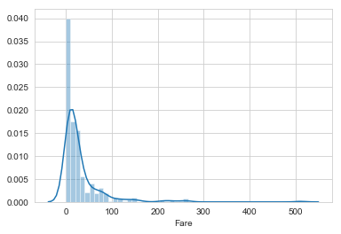

```python
sns.distplot(train['Fare'])
```

```python
#Training and Test Sets
X_train = train.drop("Survived",axis=1)
y_train = train["Survived"]
X_test  = test.drop("PassengerId",axis=1)
```

```python
#Logistic Regression
logreg = LogisticRegression()
logreg.fit(X_train, y_train)
Y_pred = logreg.predict(X_test)
logreg.score(X_train, y_train)
```

```
0.8110236220472441
```

```python
#Support Vector Machines
svc = SVC()
svc.fit(X_train, y_train)
log_Y_pred = svc.predict(X_test)
svc.score(X_train, y_train)
```

```
0.8695163104611924
```

```python
#Random Forests
random_forest = RandomForestClassifier(n_estimators=100)
random_forest.fit(X_train, y_train)
Best_Y_pred = random_forest.predict(X_test)
random_forest.score(X_train, y_train)
```

```
0.9651293588301463
```

```python
#KNN
knn = KNeighborsClassifier(n_neighbors = 3)
knn.fit(X_train, y_train)
Y_pred = knn.predict(X_test)
knn.score(X_train, y_train)
```

```
0.8368953880764904
```

```python
#Gaussian Naive Bayes
gaussian = GaussianNB()
gaussian.fit(X_train, y_train)
Y_pred = gaussian.predict(X_test)
gaussian.score(X_train, y_train)
```

```
0.7694038245219348
```

```python
#Correlation Coefficients for each feature using Logistic Regression
coeff_df = pd.DataFrame(train.columns.delete(0))
coeff_df.columns = ['Features']
coeff_df["Coefficient Estimate"] = pd.Series(logreg.coef_[0])
coeff_df
```

|  | Features | Coefficient Estimate |
| --- | --- | --- |
| 0 | Pclass | 0.349234 |
| 1 | Age | -0.037648 |
| 2 | SibSp | -0.313685 |
| 3 | Parch | -0.075883 |
| 4 | Fare | 0.002998 |
| 5 | male | -2.547567 |
| 6 | Q | -0.015514 |
| 7 | S | -0.339521 |
| 8 | 1 | 1.870282 |
| 9 | 2 | 0.620047 |
| 10 | 3 | -0.920380 |

```python
submission = pd.DataFrame({
        "PassengerId": test["PassengerId"],
        "Survived": Best_Y_pred
    })
submission.to_csv('titanic.csv', index=False)
```